# Chapter 3: Logistic Regression.

## 3.2.Data Analysis.

### 3.2.2.Reading of the dataframe “alc”, its description and printing of variables’ names.

In this chapter, we will analyze a dataset resulted from the data wrangling of another [dataset](https://archive.ics.uci.edu/ml/datasets/Student+Performance) about students’ performance in high school in mathematics and portugese language. Hereinafter are the variable of the dataset we are going to analyze:

```
##  [1] "school"     "sex"        "age"        "address"    "famsize"
##  [6] "Pstatus"    "Medu"       "Fedu"       "Mjob"       "Fjob"
## [11] "reason"     "nursery"    "internet"   "guardian"   "traveltime"
## [16] "studytime"  "failures"   "schoolsup"  "famsup"     "paid"
## [21] "activities" "higher"     "romantic"   "famrel"     "freetime"
## [26] "goout"      "Dalc"       "Walc"       "health"     "absences"
## [31] "G1"         "G2"         "G3"         "alc_use"    "high_use"
```

Alltogether the dataset has a dimension of:

```
## [1] 382  35
```

### 3.2.3.Choosing four interesting variables, and hypotesis’ formulation in relation to alcohol consumption.

I choose four variables of interest on which I build some hypotheses:

| VARIABLE CHOSEN | RELATED HYPOTHESIS |
| --- | --- |
| `"goout"` | *H1:* Students who go out more have higher alcohol consumption. |
| `"freetime"` | *H2:* Students who have more free time are more prone to drink. |
| `"studytime"` | *H3:* The more the studytime, the less a student drinks. |
| `"romantic"` | *H4:* Given the courting dynamics, romantics drink less. |

### 3.2.4.Numerical and graphical exploration of variables distribution in relation to alcohol consumption.

Let’s start with a graphical overview of the dataset variable distribution, in relation to the alcohol consumption. By installing and calling `"tidyr"`, `"dplyr"`, and `"ggplot2"`, and then by combining the function `glimpse()` via the pipe operator `%>%` to the plot generating function `ggplot()`; we get the following plot:

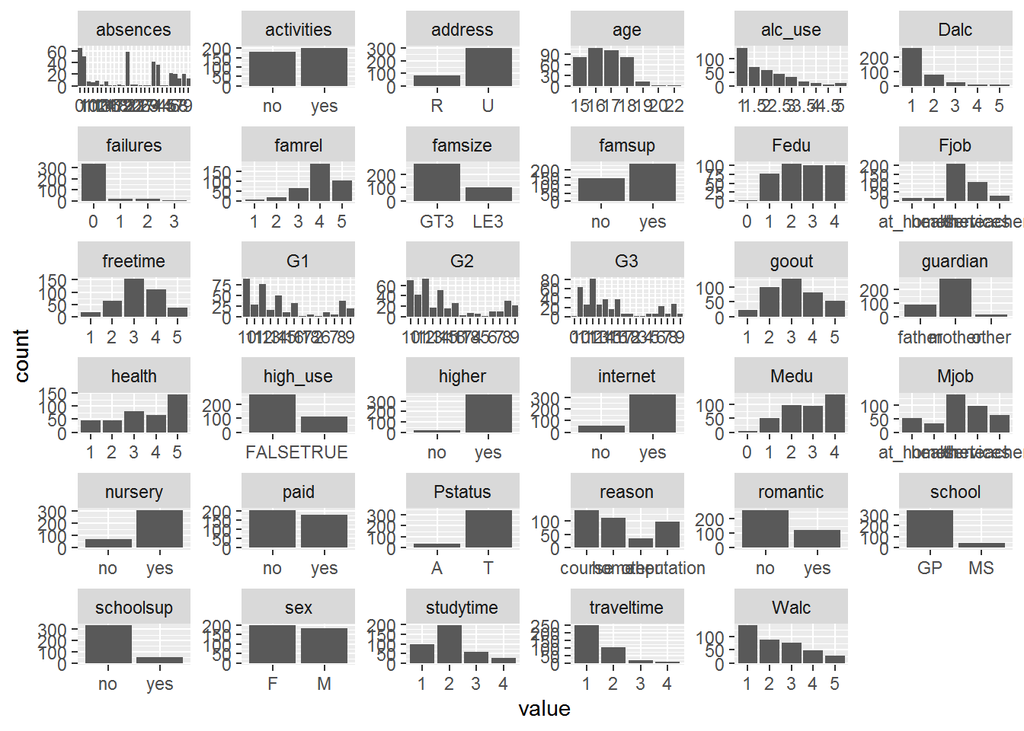

#### Cross-tabulations.

Let’s now focus on the cross-tabulations for the specific interest variables on which hypotheses were posed:

###### Go out *and* Alcohol use.

```
## # A tibble: 38 x 4
## # Groups:   goout [5]
##    goout alc_use count mean_grade
##    <int>   <dbl> <int>      <dbl>
##  1     1     1      14       11.1
##  2     1     1.5     3        7
##  3     1     2       2       13.5
##  4     1     2.5     2       12
##  5     1     3.5     1       10
##  6     2     1      49       12.6
##  7     2     1.5    21       12.1
##  8     2     2      14       10.3
##  9     2     2.5     8       12.4
## 10     2     3       4       10.8
## # ... with 28 more rows
```

###### Free time *and* Alcohol use.

```
## # A tibble: 37 x 4
## # Groups:   freetime [5]
##    freetime alc_use count mean_grade
##       <int>   <dbl> <int>      <dbl>
##  1        1     1      10       10.3
##  2        1     1.5     1       16
##  3        1     2       4       12.2
##  4        1     3       1       10
##  5        1     4       1        8
##  6        2     1      18       13.3
##  7        2     1.5    24       12.9
##  8        2     2       7       10.3
##  9        2     2.5     8       11.8
## 10        2     3       6       10.7
## # ... with 27 more rows
```

###### Study time *and* Alcohol use.

```
## # A tibble: 30 x 4
## # Groups:   studytime [4]
##    studytime alc_use count mean_grade
##        <int>   <dbl> <int>      <dbl>
##  1         1     1      21      12.2
##  2         1     1.5    20      10
##  3         1     2      17      10.1
##  4         1     2.5    10      11.5
##  5         1     3      12      10.1
##  6         1     3.5    11       9.09
##  7         1     4       4      13
##  8         1     5       5       9.6
##  9         2     1      72      11.7
## 10         2     1.5    35      12.1
## # ... with 20 more rows
```

###### Romantic *and* Alcohol use.

```
## # A tibble: 18 x 4
## # Groups:   romantic [2]
##    romantic alc_use count mean_grade
##    <fct>      <dbl> <int>      <dbl>
##  1 no           1      98      12.3
##  2 no           1.5    47      11.8
##  3 no           2      35      11.3
##  4 no           2.5    32      11.8
##  5 no           3      25      10.4
##  6 no           3.5    13      11.1
##  7 no           4       6      10.3
##  8 no           4.5     1      10
##  9 no           5       4      10
## 10 yes          1      42      11.1
## 11 yes          1.5    22      11.2
## 12 yes          2      24      11.2
## 13 yes          2.5    12      11.7
## 14 yes          3       7       8.71
## 15 yes          3.5     4       7.5
## 16 yes          4       3      10
## 17 yes          4.5     2      11
## 18 yes          5       5      11.6
```

#### Bar plots.

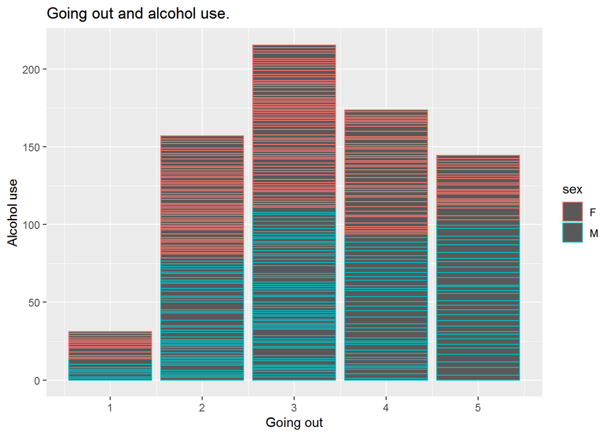

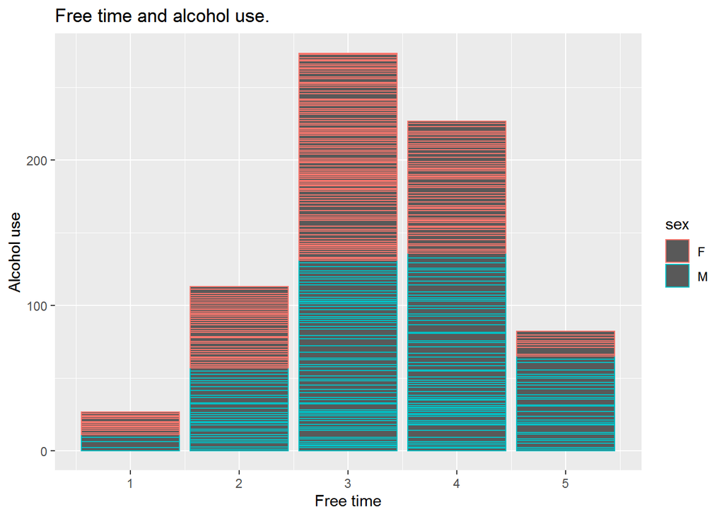

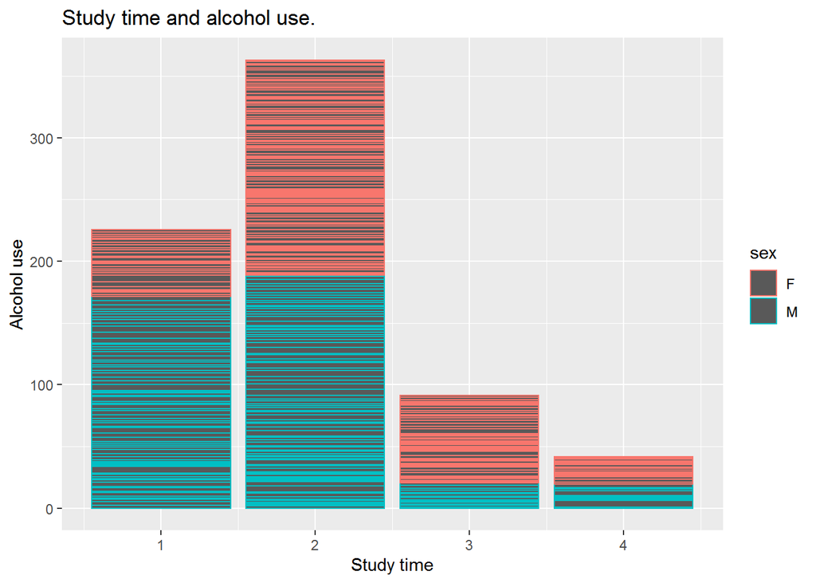

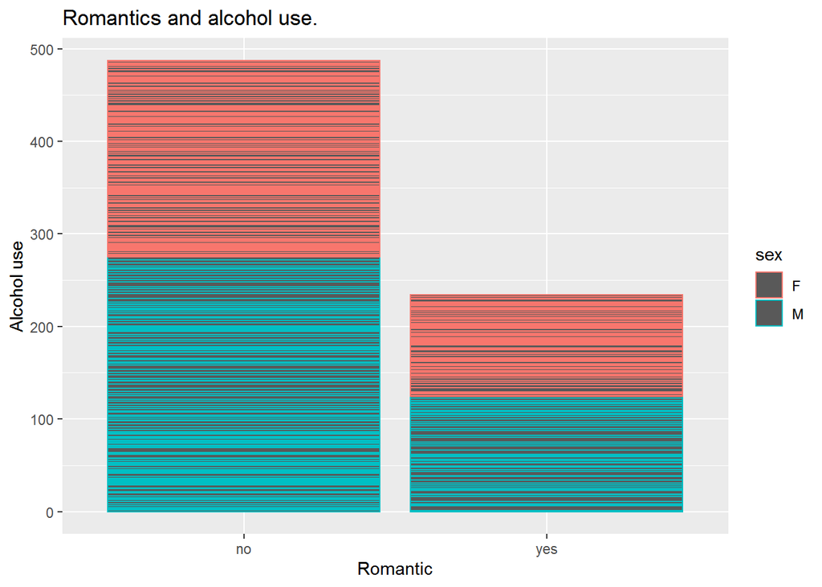

#### Box plots.

[figure not shown]

[figure not shown]

[figure not shown]

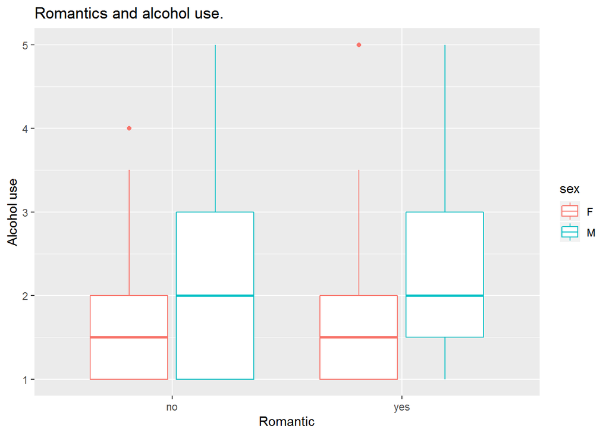

#### Comments on findings and result comparation against previous hypotheses.

##### `"goout"` and *H1*.

Concerning the variable `"goout"`, I hypotesized (*H1*) that students who go out more experiences higher alcohol consumption. Overall, it seems that people who go out more, have higher consumptions of alcohol. The most starking differences are between class 1 and 3. But people at 2 have higher consumptions than people at 5.The higher consumption is registered at 3. So it is not self-evident that the more a student goes out, the more drinks, the hypothesis *H1* is not entirely correct.

##### `"freetime"` and *H2*.

In regards to the variable `"freetime"`, its related hypothesis (*H2*) was that students who have more free time are more prone to drink. Again, the levels for the answers 3 - 4 are much higher than 1 - 2 and 5. On a general level the hypothesis *H2* seems correct. But the distributions of the results see a stark decrease at 5, which has even lower levels than at 2.

##### `"studytime"` and *H3*.

When it comes to the findings of the variable `"studytime"`, it seems to corroborate the hypothesis (*H3*) according to which the more the studytime, the less a student drinks. The value in 2 is higher than 1 but the consumption decreases at the increasing of the studytime.

##### `"romantic"` and *H4*.

Finally, to the variable `"romantic"`, I associated the hypothesis (*H4*) that romantics drink less than non-romantics, due to courting dynamics. The results seem to confirm the hypothesis *H4*. We see that non-romantics drink as much as twice compared to romantics, males percentage is higher than female one in this category, with a slightly larger gap in non-romantic.

### 3.2.5.Logistic regression.

By using logistic regression we statistically explore the relationship between the four selected variables and the binary high/low alcohol consumption variable as the target variable.

#### Summary of the fitted model and its interpretation.

```
##
## Call:
## glm(formula = high_use ~ goout + freetime + studytime + romantic,
##     family = "binomial", data = alc)
##
## Deviance Residuals:
##     Min       1Q   Median       3Q      Max
## -1.6927  -0.7743  -0.5479   1.0022   2.6060
##
## Coefficients:
##             Estimate Std. Error z value Pr(>|z|)
## (Intercept) -2.31564    0.62593  -3.700 0.000216 ***
## goout        0.72871    0.12071   6.037 1.57e-09 ***
## freetime     0.08366    0.13415   0.624 0.532863
## studytime   -0.58629    0.16508  -3.552 0.000383 ***
## romanticyes -0.18301    0.26722  -0.685 0.493442
## ---
## Signif. codes:  0 '***' 0.001 '**' 0.01 '*' 0.05 '.' 0.1 ' ' 1
##
## (Dispersion parameter for binomial family taken to be 1)
##
##     Null deviance: 465.68  on 381  degrees of freedom
## Residual deviance: 399.98  on 377  degrees of freedom
## AIC: 409.98
##
## Number of Fisher Scoring iterations: 4
```

##### Interpretation of the coefficients of the model as odd ratios, provision of confidence intervals for them.

```
## (Intercept)       goout    freetime   studytime romanticyes
## -2.31564309  0.72871166  0.08366382 -0.58628767 -0.18300551
```

Odd ratio (OR) is obtained with the division of the odds of “success” (*Y* = 1) for students who have the property *X*, by the odds of “success” of those who have **not**. As OR quantifies the relations between *X* and *Y*, Odds **higher than 1** indicates that *X* is **positively associated** with “success”. The odds ratios can be seen also as exponents of the coefficients of a logistic regression model.

Computation of the odds ratio (OR)

Computation of the confidence intervals for the coefficients by the function `confint()`, and exponentiation of the values by using `exp()`.

```
##                  2.5 %     97.5 %
## (Intercept) -3.5691044 -1.1092870
## goout        0.4982923  0.9725916
## freetime    -0.1795761  0.3477794
## studytime   -0.9207772 -0.2716715
## romanticyes -0.7148612  0.3353712
```

Obtaining the odds ratio with their confidence intervals by using `cbind()`:

```
##                     OR      2.5 %    97.5 %
## (Intercept) 0.09870269 0.02818108 0.3297940
## goout       2.07240892 1.64590816 2.6447898
## freetime    1.08726331 0.83562438 1.4159199
## studytime   0.55638895 0.39820941 0.7621045
## romanticyes 0.83276356 0.48926002 1.3984594
```

### 3.2.6.Predictive power of the model.

First we use the function to `predict()` the probability of high use, after modifying the dataset `'alc'` with the new integration we move to predict probabilities and classes, and to tabulate the target variables versus the predictions:

```
##     goout freetime studytime romantic probability prediction
## 373     2        3         1       no  0.23263069      FALSE
## 374     3        4         1       no  0.40585185      FALSE
## 375     3        3         3       no  0.16282192      FALSE
## 376     3        4         1      yes  0.36258869      FALSE
## 377     2        4         3       no  0.09258880      FALSE
## 378     4        3         2       no  0.42009575      FALSE
## 379     2        2         2       no  0.13429940      FALSE
## 380     1        1         2       no  0.06441395      FALSE
## 381     5        4         1       no  0.74578989       TRUE
## 382     1        4         1       no  0.13722123      FALSE
```

##### Cross tabulations and actual values *vs* predictions graphic.

```
##         prediction
## high_use FALSE TRUE
##    FALSE   247   21
##    TRUE     73   41
```

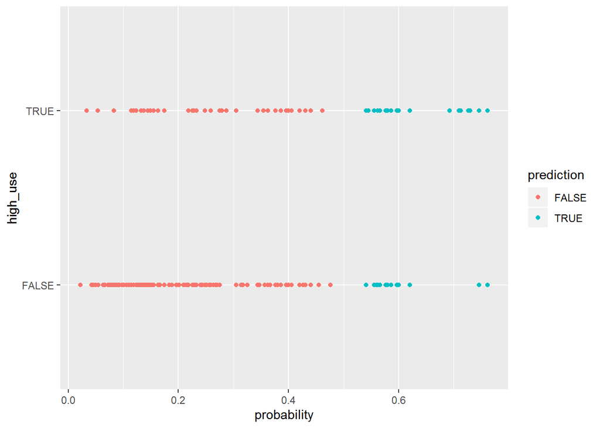

```
##         prediction
## high_use      FALSE       TRUE        Sum
##    FALSE 0.64659686 0.05497382 0.70157068
##    TRUE  0.19109948 0.10732984 0.29842932
##    Sum   0.83769634 0.16230366 1.00000000
```

##### Training error, and result comments. Model performance *vs* guessing.

Accuracy measures the performance in binary classifications as the average number of correctly classified observations. The mean of incorrectly classified observations can be seen as a penalty function of the classifier: the less the better. In this section, first we define a loss function `loss_func()`, and then we apply it to probability = 0, probability = 1 and then to the prediction probabilities in `alc`.

```
## [1] 0.2984293
```

```
## [1] 0.7015707
```

```
## [1] 0.2460733
```

The first and third functions deliver better results than in the case of probability = 1. It works better than guessing.

### 3.2.7. **Bonus**: 10-fold model cross-validation.

Cross validation is a technique to assess how the results of a statistical analysis will generalize to an independent data set. In a cross validation, a sample of data is partitioned into complementary subsets (training, larger and testing, smaller), performing the analysis on the former and validating the results on the latter. The subsets used here are K = 10.

```
## [1] 0.2460733
```

With leave-one-out cross validation:

```
## [1] 0.2460733
```

with 10-fold cross validation:

```
## [1] 0.2460733
```

At first I use a logistic regression model with 22 predictors.

```
## [1] 0.2460733
```

The function is performed with leave-one-out cross validation.

```
## [1] 0.2539267
```

Here the result is given by ten-fold cross validation.

```
## [1] 0.2539267
```

With 15 predictors

The function is performed with leave-one-out cross validation.

```
## [1] 0.2696335
```

Here the result is given by ten-fold cross validation.

```
## [1] 0.2748691
```

With 10 predictors

The function is performed with leave-one-out cross validation.

```
## [1] 0.2670157
```

Here the result is given by ten-fold cross validation.

```
## [1] 0.2722513
```

With 5 predictors

The function is performed with leave-one-out cross validation.

```
## [1] 0.2460733
```

Here the result is given by ten-fold cross validation.

```
## [1] 0.2486911
```